# Simulational scRNAseq data generation

ryamada

2019年9月26日

## Motivation

As the initial step, the number of reads from 100 cell pool were distributed to 100 cells stochastically.

With this procedure, the number of total reads of every cell is much smaller than the number of reads of the pool.

The number of total reads of each cell in future single cell RNA seq experiments will be similar to the number of the current pool experiments.

Therefore it would be better to generate the simulational sc-RNA seq data in that way.

The following is an idea to do so.

## Preparation

The codes below is just make an example of read counts of all genes of an experiment of 100 cell pool.

```r
library(MCMCpack) # For dirichlet distribution functions
```

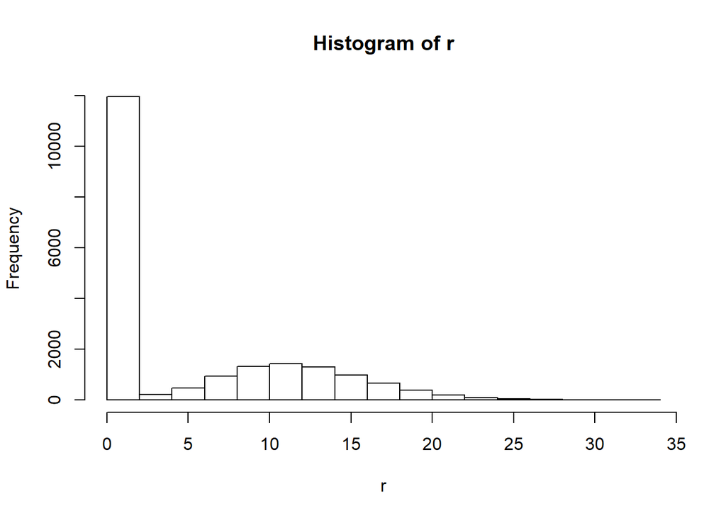

```r
n.gene <- 20000 # number of genes
# Assumption: there are two groups of genes.
# One group has low expression level
# The other group has relatively higher expression level
n.gene.1 <- n.gene*0.6
n.gene.2 <- n.gene - n.gene.1
# Total read counts per experiment...
n.read.total <- 10^5

# Fraction vector of n.gene length is generated
# Randomly generate fraction following Dirichlet distribution
p1 <- rdirichlet(1,rep(0.1,n.gene.1))
p2 <- rdirichlet(1,rep(20,n.gene.2))
# Combine two gene groups' fraction with heavy weight on the 2nd group
p <- c(p1*0.01,p2*0.99)
# Randomly generate experiment data
r <- rmultinom(1,n.read.total,prob=p)
# Showing the read counts
hist(r)
```

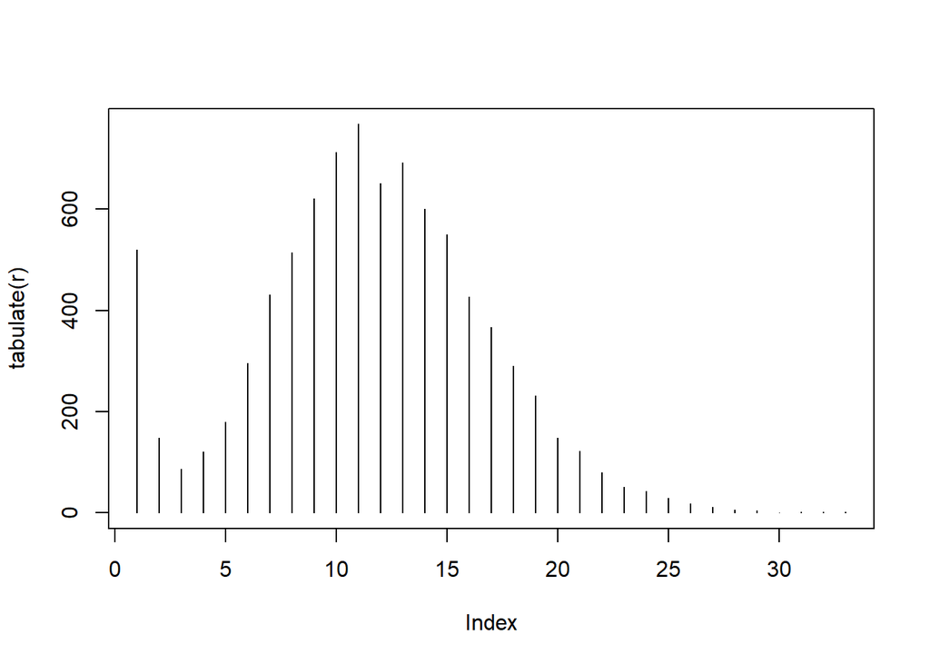

```r
plot(tabulate(r),type="h")
```

```r
sum(r) # = n.read.total
```

```
## [1] 100000
```

## Data simulation from the experiment read count vector

The estimation of fraction based on multinomial count data should be in Dirichlet distribution.

Of note, the 2nd argument for the dirichlet distribution function, rdirichlet() shoudl be r + 1 , rathere than r.

We have a multinomial count data as generated above.

The following codes generate simulational fraction vector for individual cell.

This provides some heterogeneity among cells.

```r
n.cell <- 100
sim.frac <- rdirichlet(n.cell,r + 1)
```

Secondly, we stochastically generate sc-RNAseq data for 100 cells, independently.

```r
sim.reads <- matrix(0,n.cell,n.gene)
for(i in 1:n.cell){
    sim.reads[i,] <- rmultinom(1,n.read.total,prob=sim.frac[i,])
}
```

Let’s take a look at summary statistics of read counts per gene among 100 cells.

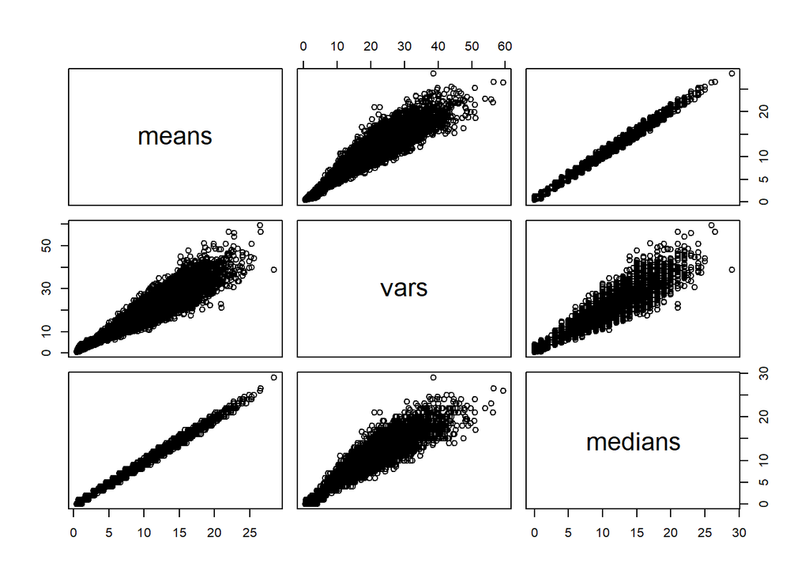

```r
means <- apply(sim.reads,2,mean)
vars <- apply(sim.reads,2,var)
medians <- apply(sim.reads,2,quantile,0.5)

pairs(cbind(means,vars,medians))
```

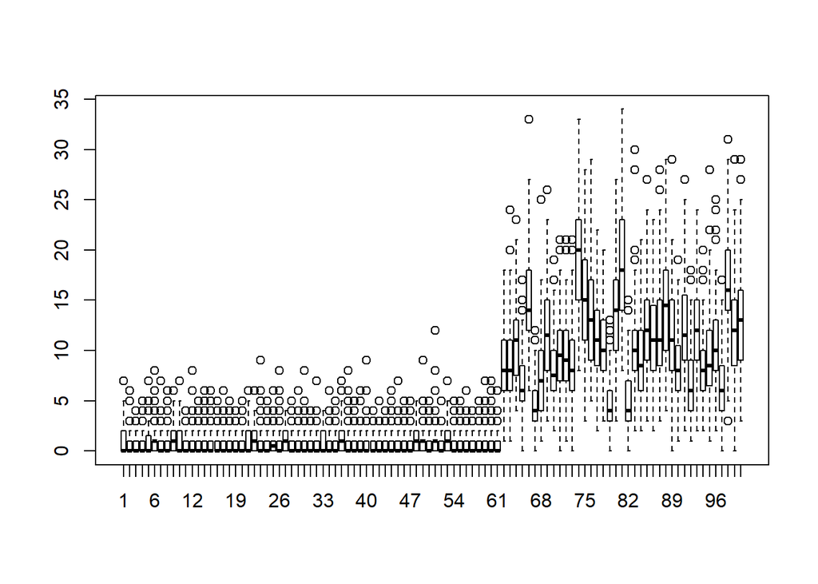

```r
pick.up.genes <- sort(sample(1:n.gene,100))
boxplot(sim.reads[,pick.up.genes])
```